# Rap Analysis - Exploration

Rap analysis

```r
library(spotifyr)
library(tidyverse)
# Get the Data

polls <- readr::read_csv('https://raw.githubusercontent.com/rfordatascience/tidytuesday/master/data/2020/2020-04-14/polls.csv')
rankings <- readr::read_csv('https://raw.githubusercontent.com/rfordatascience/tidytuesday/master/data/2020/2020-04-14/rankings.csv')
# Or read in with tidytuesdayR package (https://github.com/thebioengineer/tidytuesdayR)
# PLEASE NOTE TO USE 2020 DATA YOU NEED TO USE tidytuesdayR version from GitHub

# Either ISO-8601 date or year/week works!

# Install via devtools::install_github("thebioengineer/tidytuesdayR")

#tuesdata <- tidytuesdayR::tt_load('2020-04-14')
#tuesdata <- tidytuesdayR::tt_load(2020, week = 16)


#polls <- tuesdata$polls
```

# polls.csv

variable class description rank double Rank given by voter (1-5) title character Title of song artist character Artist gender character Gender of artist year double Year song released critic_name character Name of critic critic_rols character Critic’s role critic_country character Critic’s primary country critic_country2 character Critic’s secondary country

# rankings.csv

variable class description ID double ID of song title character Title of song artist character Artist’s name year double Year song released gender character Gender of artist/group points double Total points awarded n double Total votes (regardless of position) n1 double Number of votes as #1 n2 double Number of votes as #2 n3 double Number of votes as #3 n4 double Number of votes as #4 n5 double Number of votes as #5

```r
cid <- Sys.getenv('SPOTIFY_CLIENT_ID')
cs <- Sys.getenv('SPOTIFY_CLIENT_SECRET')

access_token <- get_spotify_access_token(client_id = Sys.getenv('SPOTIFY_CLIENT_ID'),
                                         client_secret = Sys.getenv('SPOTIFY_CLIENT_SECRET'))
```

```r
### every noise
# http://everynoise.com/everynoise1d.cgi?root=edm
subgenres <- data.frame(genre = c(rep('rap',4)),
                      subgenre = c('hip hop', 'southern hip hop', 'gangster rap', 'trap'),
                      stringsAsFactors = FALSE)

playlist_ids <- NULL

for(g in seq_along(subgenres$subgenre)){

  out <- search_spotify(q = subgenres$subgenre[g], type = 'playlist', market = 'US', limit = 20)
  out <- out %>%
    select(name, id) %>%
    mutate(subgenre = subgenres$subgenre[g],
           genre = subgenres$genre[g])

  playlist_ids <- rbind(playlist_ids, out)

}
```

```r
# get the track ids
playlist_songs <- NULL

for(p in seq_along(playlist_ids$id)){

  out <- get_playlist_tracks(playlist_id = playlist_ids$id[p])

  out <- out %>%
    filter(!is.na(track.id)) %>%
    # separate out the df column artists
    unnest(cols = 'track.artists') %>%
    group_by(track.id) %>%
    mutate(row_number = 1:n(),
           track.artist = name) %>%
    ungroup() %>%
    filter(row_number == 1) %>%
    select(track.id, track.name, track.artist, track.popularity, track.album.id, track.album.name, track.album.release_date) %>%
    mutate(playlist_name = playlist_ids$name[p],
           playlist_id = playlist_ids$id[p],
           playlist_genre = playlist_ids$genre[p],
           playlist_subgenre = playlist_ids$subgenre[p])

  playlist_songs <- rbind(playlist_songs, out)

}
```

```r
get_track_audio_features_over_100 <- function(ids) {

  ## spotifyr limits get_track_audio_features to 100 at a time
  ## this function loops through the full id list

  ids <- ids[!is.na(ids)]
  len <- length(ids)
  repetitions <- floor(len/100) * 100
  intervals <- c(seq(from = 0, to = repetitions, by = 100), len)

  features <- data.frame()
  for(r in seq_along(intervals)){
    start <- intervals[r]
    end <- intervals[r + 1] - 1
    if(is.na(end)) break

    inner_features <- get_track_audio_features(ids = ids[start:end])
    features <- rbind(features, inner_features)

  }

  return(features)

}
```

```r
# get track audio features
playlist_audio <- get_track_audio_features_over_100(ids = playlist_songs$track.id)

# combine
playlist_songs <- playlist_songs %>%
  left_join(select(playlist_audio, -track_href, -uri, -analysis_url, -type, -time_signature), by = c('track.id' = 'id')) %>%
  unique() %>%
  filter(!is.na(danceability))

# handle duplicates - songs on multiple playlists
playlist_songs <- playlist_songs %>%
  group_by(playlist_genre, playlist_subgenre, track.id) %>%
  mutate(row_number = 1:n()) %>%
  filter(row_number == 1) %>%
  ungroup() %>%
  select(-row_number)

#write.csv(playlist_songs, 'genre_songs.csv', row.names=FALSE)
```

search_spotify(q, type = c(“album”, “artist”, “playlist”, “track”), market = NULL, limit = 20, offset = 0, include_external = NULL, authorization = get_spotify_access_token(), include_meta_info = FALSE)

```r
b <- search_spotify(q="Shinjitsu No Dangan", 'track', limit=20)

# get_playlist_audio_features("tmock1923", "7e5")
```

```r
pull_id <- function(query) {
  search_spotify(query, "track") %>%
    arrange(-popularity) %>%
    filter(row_number() == 1) %>%
    pull(id)
}
access_token <- get_spotify_access_token(client_id = Sys.getenv('SPOTIFY_CLIENT_ID'),
                                         client_secret = Sys.getenv('SPOTIFY_CLIENT_SECRET'))
ranking_ids <- rankings %>%
  mutate(searchquery = paste(title, artist),
         searchquery = str_to_lower(searchquery),
         searchquery = str_remove(searchquery, "ft.*$")) %>%
  mutate(id = map_chr(searchquery, possibly(pull_id, NA_character_)))
```

1.93%

```r
ranking_features <- ranking_ids %>%
  mutate(id_group = row_number() %/% 80) %>%
  select(id_group, id) %>%
  nest(data = c(id)) %>%
  mutate(audio_features = map(data, ~get_track_audio_features(.$id)))
```

```r
rankings_df <- ranking_ids %>%
  bind_cols(ranking_features %>%
              select(audio_features) %>%
              unnest(audio_features)) %>%
  select(title, artist, points, year, danceability:tempo) %>%
  na.omit()
```

```
Correlation method: 'pearson'
Missing treated using: 'pairwise.complete.obs'
```

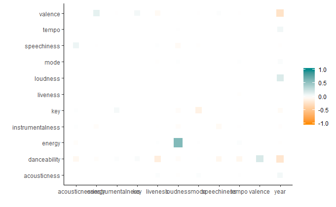

```r
library(corrr)

rankings_df %>%
  select(year:tempo) %>%
  correlate() %>%
  rearrange() %>%
  shave() %>%
  rplot(shape = 15, colors = c("darkorange", "white", "darkcyan"))
```

```r
NA
```

```r
ranking_lm <- rankings_df %>%
  select(-title, -artist) %>%
  lm(log(points) ~ ., data = .)

summary(ranking_lm)
```

```
Call:
lm(formula = log(points) ~ ., data = .)

Residuals:
     Min       1Q   Median       3Q      Max
-1.74734 -0.57186  0.04495  0.43141  2.66998

Coefficients:
                  Estimate Std. Error t value Pr(>|t|)
(Intercept)      64.603559  13.723105   4.708 3.95e-06 ***
year             -0.031233   0.006744  -4.631 5.58e-06 ***
danceability      0.088747   0.434773   0.204    0.838
energy            0.034760   0.433454   0.080    0.936
key               0.004287   0.013739   0.312    0.755
loudness          0.035091   0.022764   1.541    0.124
mode             -0.078376   0.103268  -0.759    0.449
speechiness      -0.182031   0.408076  -0.446    0.656
acousticness      0.442155   0.300148   1.473    0.142
instrumentalness  0.621053   0.622244   0.998    0.319
liveness          0.140567   0.262802   0.535    0.593
valence          -0.336922   0.286438  -1.176    0.240
tempo             0.001175   0.001637   0.718    0.473
---
Signif. codes:  0 ‘***’ 0.001 ‘**’ 0.01 ‘*’ 0.05 ‘.’ 0.1 ‘ ’ 1

Residual standard error: 0.8285 on 280 degrees of freedom
Multiple R-squared:  0.09559,   Adjusted R-squared:  0.05683
F-statistic: 2.466 on 12 and 280 DF,  p-value: 0.004471
```

## Principal component analysis

```r
library(tidymodels)
library(forcats)

ranking_rec <- recipe(points ~ ., data = ranking_df) %>%
  update_role(title, artist, new_role = "id") %>%
  step_log(points) %>%
  step_normalize(all_predictors()) %>%
  step_pca(all_predictors())

ranking_prep <- prep(ranking_rec)
```

[figure not shown]

```r
tidied_pca <- tidy(ranking_prep, 3)

tidied_pca %>%
  mutate(component = fct_inorder(component)) %>%
  ggplot(aes(value, terms, fill = terms)) +
  geom_col(show.legend = FALSE) +
  facet_wrap(~component) +
  labs(y = NULL)
```

[figure not shown]